# NYC Air Quality

Minh Tran

11-14-2024

# New York City air quality surveillance report

## Data preparation

```r
knitr::opts_chunk$set(echo = F, warning = FALSE, message = FALSE)
library(readr)
library(ggplot2)
library(tidyverse)
library(cowplot)
```

```
## Rows: 18,025
## Columns: 12
## $ `Unique ID`      <dbl> 179772, 179785, 178540, 178561, 823217, 177910, 17795…
## $ `Indicator ID`   <dbl> 640, 640, 365, 365, 365, 365, 365, 365, 365, 365, 365…
## $ Name             <chr> "Boiler Emissions- Total SO2 Emissions", "Boiler Emis…
## $ Measure          <chr> "Number per km2", "Number per km2", "Mean", "Mean", "…
## $ `Measure Info`   <chr> "number", "number", "mcg/m3", "mcg/m3", "mcg/m3", "mc…
## $ `Geo Type Name`  <chr> "UHF42", "UHF42", "UHF42", "UHF42", "UHF42", "UHF42",…
## $ `Geo Join ID`    <dbl> 409, 209, 209, 409, 409, 209, 209, 409, 409, 410, 209…
## $ `Geo Place Name` <chr> "Southeast Queens", "Bensonhurst - Bay Ridge", "Benso…
## $ `Time Period`    <chr> "2015", "2015", "Annual Average 2012", "Annual Averag…
## $ Start_Date       <chr> "01/01/2015", "01/01/2015", "12/01/2011", "12/01/2011…
## $ `Data Value`     <dbl> 0.3, 1.2, 8.6, 8.0, 6.1, 10.0, 9.8, 9.8, 9.6, 7.2, 8.…
## $ Message          <lgl> NA, NA, NA, NA, NA, NA, NA, NA, NA, NA, NA, NA, NA, N…
```

## 1. Road traffic

- Let’s look at how road traffic contributes to air pollution by looking at the number of miles traveled by cars and trucks.

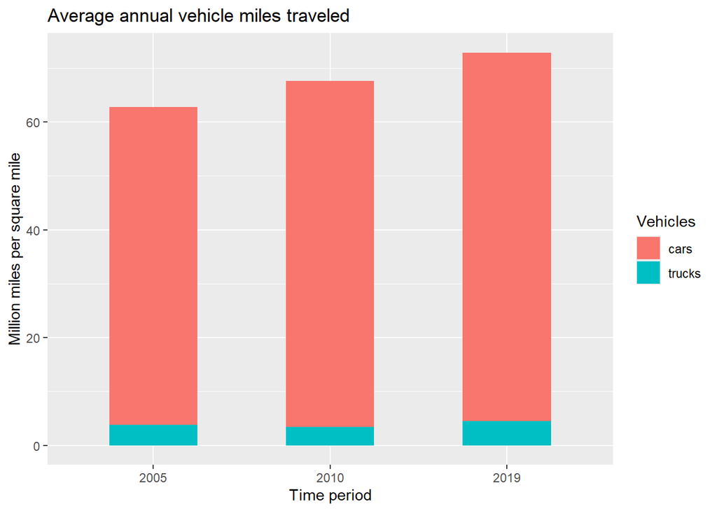

- It’s obviously that the number of miles traveled by cars and trucks increased from 2005 to 2019. In which, 3.767290 million miles per square mile to 4.477570 million miles per square mile for trucks, and 62.80374 million miles per square mile in 2005 to 72.91121 million miles per square mile in 2019 for car.
- To better understand how road traffic is affecting air quality, let’s look at the toxic chemicals emitted from this factor. Here we will examine the measured amounts of Benzene, Nitrogen dioxide (NO2) and Formaldehyde. These three substances are mainly produced from Vehicles Exhaust Systems during the combustion process of the engines. Hence, let’s look at how much they were released into the air.

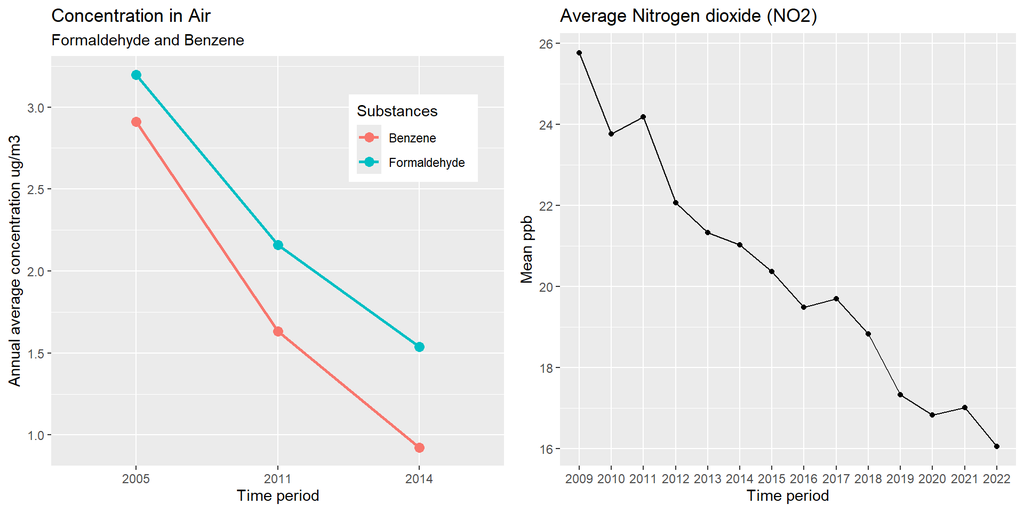

## 2. Ozone

- According to Copernicus, the European Union’s Earth observation program, Ozone is a major air quality hazard in the summer because of the weather conditions that favor its formation. This would be the reason why the dataset just record the Ozone amount during summers from 2009 to 2022.
- Before we look at how Ozone concentration has changed , let’s look at how the Ozone observations around NYC differs in 2009 and 2022. The unit for Ozone is ppb which means Parts per billion.

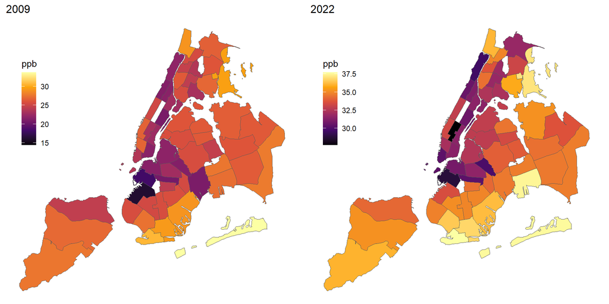

- From the above two NYC maps showing the data of Ozone, we see that,in overall, the ozone levels have increased (slightly or highly) in all areas (switching from dark to light colors in 2022). To get more details about the changes, let find out which area or neighborhood has the lowest Ozone concentration in 2009, and see how it has changed in 2022.

```
## # A tibble: 1 × 3
##   `Geo Join ID` `Geo Place Name` ppb_amout_2009
##           <dbl> <chr>                     <dbl>
## 1           105 Midtown (CD5)              14.4
```

- We see that Midtown (CD5) had the lowest Ozone concentration in 2009, let see how it changed in 2022

Change of Ozone Concentration for Midtown (CD5) from 2009 to 2022

[output not shown]

- It is clear that the amount of ozone has increased significantly. It has certainly caused a lot of health-related problems to people in NYC. Here, the dataset also reported the number of cases related to Asthma emergency departments or hospitalization, Cardiac and respiratory deaths , all due to Ozone. But I will analyze those numbers when comparing Ozone with Fine particles (PM 2.5) in terms of harmful effects in the final section.

## 3. Fine particles (PM 2.5)

- The Time Period for PM 2.5 includes “Annual Average” and a variety of seasons like “Summer 2010”, “Winter 2009”, … so here I will take the data that has the Time Period begins with “Annual Average…” to analyze, and calculate the average amount of PM 2.5 for all neighborhoods by year also.

```
##    Period     Value
## 1    2009 10.986525
## 2    2010 10.074468
## 3    2011 10.587234
## 4    2012  9.445390
## 5    2013  9.141844
## 6    2014  9.407801
## 7    2015  9.043972
## 8    2016  7.894326
## 9    2017  7.741135
## 10   2018  7.395745
## 11   2019  7.015603
## 12   2020  6.326950
## 13   2021  6.760993
## 14   2022  6.067376
```

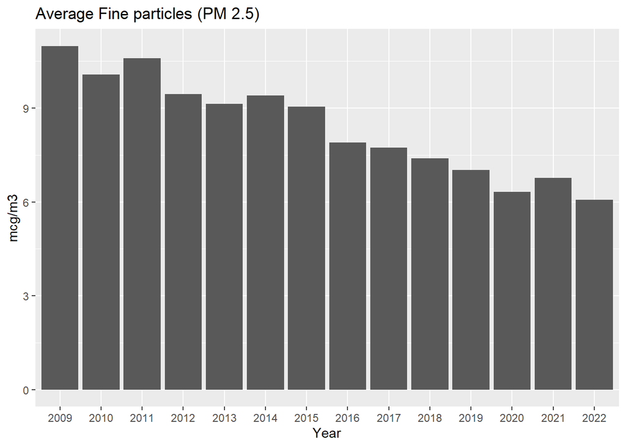

## 4. Ozone vs PM 2.5, Which one causes more damage to humans?

```
##      Period    Value Indicator
## 1 2005-2007 48.41458     Ozone
## 2 2009-2011 49.35625     Ozone
## 3 2012-2014 55.87292     Ozone
## 4 2015-2017 49.60000     Ozone
## 5 2017-2019 41.33333     Ozone
```

```
##      Period    Value Indicator
## 1 2005-2007 61.17917      PM25
## 2 2009-2011 46.74792      PM25
## 3 2012-2014 43.88958      PM25
## 4 2015-2017 35.51458      PM25
## 5 2017-2019 28.75000      PM25
```

```
##       Period    Value Indicator
## 1  2005-2007 48.41458     Ozone
## 2  2009-2011 49.35625     Ozone
## 3  2012-2014 55.87292     Ozone
## 4  2015-2017 49.60000     Ozone
## 5  2017-2019 41.33333     Ozone
## 6  2005-2007 61.17917      PM25
## 7  2009-2011 46.74792      PM25
## 8  2012-2014 43.88958      PM25
## 9  2015-2017 35.51458      PM25
## 10 2017-2019 28.75000      PM25
```

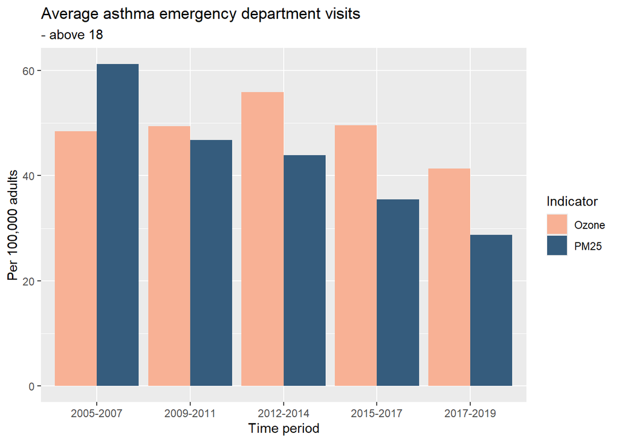

```
##      Period     Value Indicator
## 1 2005-2007  86.98958     Ozone
## 2 2009-2011 103.18750     Ozone
## 3 2012-2014 109.46042     Ozone
## 4 2015-2017  94.86458     Ozone
## 5 2017-2019  79.88679     Ozone
```

```
##      Period     Value Indicator
## 1 2005-2007 119.68542      PM25
## 2 2009-2011 100.21667      PM25
## 3 2012-2014  91.25417      PM25
## 4 2015-2017  72.85000      PM25
## 5 2017-2019  58.41667      PM25
```

```
##       Period     Value Indicator
## 1  2005-2007  86.98958     Ozone
## 2  2009-2011 103.18750     Ozone
## 3  2012-2014 109.46042     Ozone
## 4  2015-2017  94.86458     Ozone
## 5  2017-2019  79.88679     Ozone
## 6  2005-2007 119.68542      PM25
## 7  2009-2011 100.21667      PM25
## 8  2012-2014  91.25417      PM25
## 9  2015-2017  72.85000      PM25
## 10 2017-2019  58.41667      PM25
```

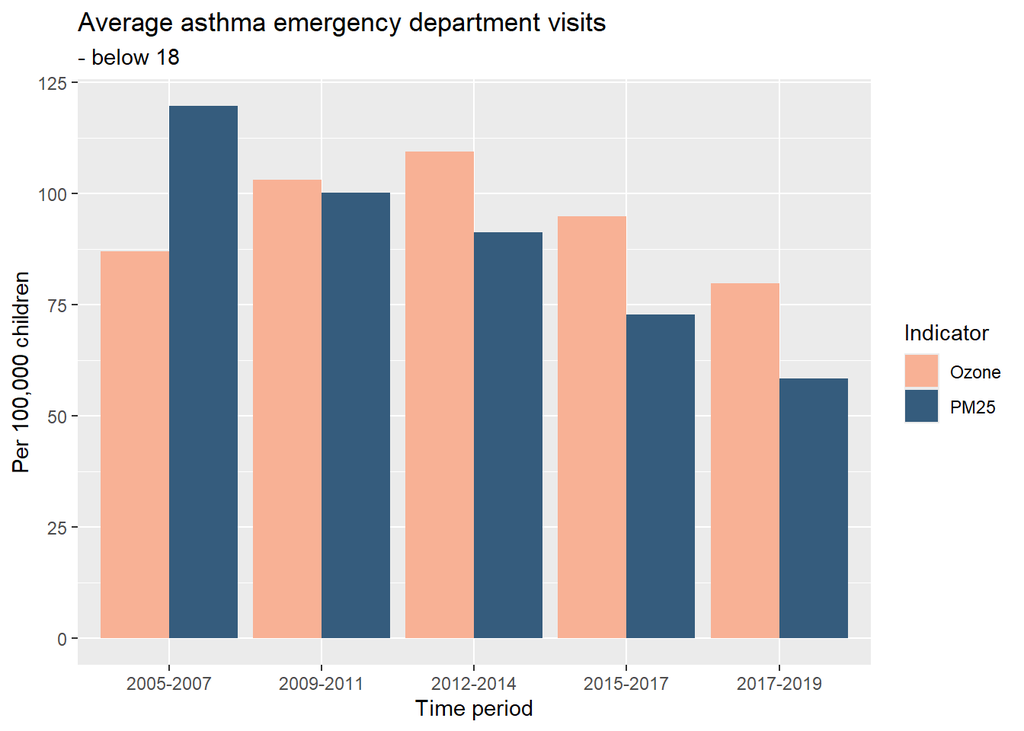

- Now we will look at the statistics on deaths caused by ozone and pm 2.5. Here I examined whether the data recorded the cases for both adults and children like the above asthma emergency department visits. But they just gave us the general Measure Info which are per 100,000 and per 100,000 adults, like the following code:

```r
# Deaths due to Ozone
child_adult <- unique(data_14$`Measure Info`)
child_adult
```

```
## [1] "per 100,000"
```

```r
data_14
```

```
## # A tibble: 240 × 12
##    `Unique ID` `Indicator ID` Name        Measure `Measure Info` `Geo Type Name`
##          <dbl>          <dbl> <chr>       <chr>   <chr>          <chr>
##  1      131006            652 Cardiac an… Estima… per 100,000    UHF42
##  2      130998            652 Cardiac an… Estima… per 100,000    UHF42
##  3      130987            652 Cardiac an… Estima… per 100,000    UHF42
##  4      828176            652 Cardiac an… Estima… per 100,000    UHF42
##  5      629176            652 Cardiac an… Estima… per 100,000    UHF42
##  6      629158            652 Cardiac an… Estima… per 100,000    UHF42
##  7      518704            652 Cardiac an… Estima… per 100,000    UHF42
##  8      518715            652 Cardiac an… Estima… per 100,000    UHF42
##  9      828179            652 Cardiac an… Estima… per 100,000    UHF42
## 10      130988            652 Cardiac an… Estima… per 100,000    UHF42
## # ℹ 230 more rows
## # ℹ 6 more variables: `Geo Join ID` <dbl>, `Geo Place Name` <chr>,
## #   `Time Period` <chr>, Start_Date <chr>, `Data Value` <dbl>, Message <lgl>
```

```r
# Deaths due to PM2.5
child_adult_pm <- unique(data_15$`Measure Info`)
child_adult_pm
```

```
## [1] "per 100,000 adults"
```

- Due to Data inconsistency like the above explanation, I will assume that the estimated death rates related to both Ozone and PM 2.5 is for adults. Let see how those rates differ in the following graph:

[output not shown]

[output not shown]

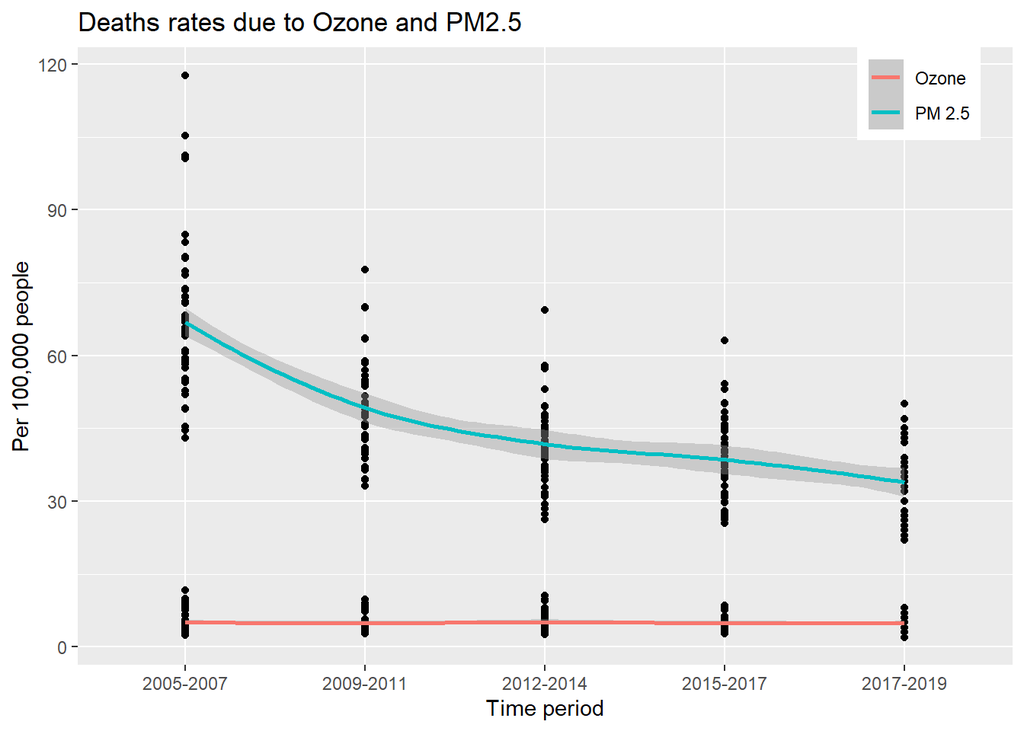

## Reference List

1. “Ozone Pollution, the Air Quality Hazard of the Summer.” Copernicus, atmosphere.copernicus.eu/ozone-pollution-air-quality-hazard-summer#:~:text=Ozone%20(O3)%2C%20is%20a,European%20Ambient%20Air%20Quality%20Directive. Accessed 19 Nov. 2024.
2. Revised air quality standards for particle … Available at: https://www.epa.gov/sites/default/files/2016-04/documents/2012_aqi_factsheet.pdf (Accessed: 23 November 2024).

## END

[output not shown]

[output not shown]